# ROC Analysis for Diabetes

Ching Yi Lam

10/25/2024

# 1 Introduction

We want to see if there is/are any variable(s) will cause the diabetes. We have 9 variables in our dataset. One of the variable is diabetes which indicates if the person has diabetes or not.

## 1.1 Questions to think of for this dataset

1. Is the gender correlated to diabetes?
2. Is age correlated to diabetes? If age will be a possible chance to cause diabetes such as if the person is older that will be a higher chance to have diabetes.
3. Is history of heart disease correlated to diabetes?
4. Is smoking history correlated to diabetes?
5. Is it possible that the higher BMI, the higher chance to have diabetes?
6. Is blood glucose level correlated to diabetes?

# 2 Description of Data

The Diabetes prediction dataset comprises medical and demographic information from patients, along with their diabetes diagnosis status which is positive or negative. It includes features such as age, gender, body mass index (BMI), hypertension, heart disease, smoking history, HbA1c levels, and blood glucose levels. This data set is collected from my professor’s teaching data repository. This dataset has 100000 records and 9 variables. All of the variables do not have missing value. A detailed description of the variables is given below:

`Gender`: Gender refers to the biological sex of the individual: Female, Male, and Other.

`Age`: Age ranges from 0-80 for the individual in our dataset.

`Hypertension`: Hypertension is a health condition characterized by consistently high blood pressure in the arteries. 0 indicates they do not have hypertension, and 1 indicates they have hypertension.

`Heart_disease`: Heart disease is a medical condition linked to a higher risk of developing diabetes. 0 indicates they do not have heart disease, and 1 indicates they have heart disease.

`HbA1c_level`: HbA1c (Hemoglobin A1c) level reflects a person’s average blood sugar over the past 2 to 3 months. Higher HbA1c levels signify a higher risk of developing diabetes. Mostly more than 6.5% of HbA1c level indicates diabetes.

`Blood_glucose_level`: Blood glucose level indicates the concentration of glucose in the bloodstream at a specific moment. Higher blood glucose levels are a primary indicator of diabetes.

`Diabetes`: Diabetes is the target variable being predicted. 0 indicates the absence of diabetes, and 1 indicates the presence of diabetes.

A copy of this publicly available data is stored at https://pengdsci.github.io/datasets/bin-DiabetesPred/diabetes_prediction_dataset.csv.

```r
diabetes = read.csv("https://pengdsci.github.io/datasets/bin-DiabetesPred/diabetes_prediction_dataset.csv", stringsAsFactors = TRUE)
summary(diabetes)
```

```
    gender           age         hypertension     heart_disease
 Female:58552   Min.   : 0.08   Min.   :0.00000   Min.   :0.00000
 Male  :41430   1st Qu.:24.00   1st Qu.:0.00000   1st Qu.:0.00000
 Other :   18   Median :43.00   Median :0.00000   Median :0.00000
                Mean   :41.89   Mean   :0.07485   Mean   :0.03942
                3rd Qu.:60.00   3rd Qu.:0.00000   3rd Qu.:0.00000
                Max.   :80.00   Max.   :1.00000   Max.   :1.00000
    smoking_history       bmi         HbA1c_level    blood_glucose_level
 current    : 9286   Min.   :10.01   Min.   :3.500   Min.   : 80.0
 ever       : 4004   1st Qu.:23.63   1st Qu.:4.800   1st Qu.:100.0
 former     : 9352   Median :27.32   Median :5.800   Median :140.0
 never      :35095   Mean   :27.32   Mean   :5.528   Mean   :138.1
 No Info    :35816   3rd Qu.:29.58   3rd Qu.:6.200   3rd Qu.:159.0
 not current: 6447   Max.   :95.69   Max.   :9.000   Max.   :300.0
    diabetes
 Min.   :0.000
 1st Qu.:0.000
 Median :0.000
 Mean   :0.085
 3rd Qu.:0.000
 Max.   :1.000
```

```r
# We create a new column in our dataset with spaces replaced by underscores in smoking_history. This method is to avoid a string error when we are creating the model formula.

diabetes$new_smoking_history <- gsub(" ", "_", diabetes$smoking_history)
```

## 2.1 Summary of Categorical Data

In this section, we see the summary of the gender, hypertension, heart disease, smoking history, and diabetes.

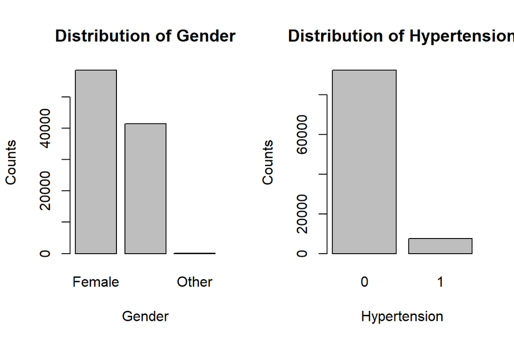

```r
par(mfrow=c(1,2))
freq.tbl_1 = table(diabetes$gender)
barplot(freq.tbl_1, xlab="Gender", ylab = "Counts", main="Distribution of Gender")
freq.tbl_2 = table(diabetes$hypertension)
barplot(freq.tbl_2, xlab="Hypertension", ylab = "Counts", main="Distribution of Hypertension")
```

- The graph on the left represents the distribution of gender, we can see that the female distribution is higher than male and other.
- The graph on the right represents the hypertension which 0 indicates the person does not have hypertension, and 1 indicates the person have hypertension. We can see that there are more people does not have hypertension.

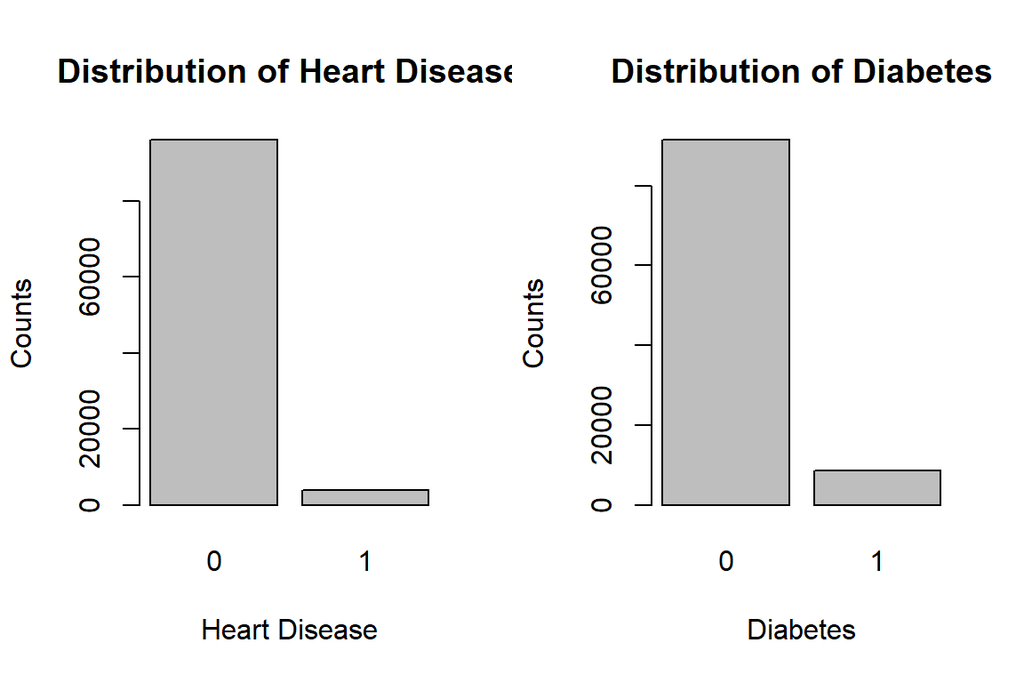

```r
par(mfrow=c(1,2))
freq.tbl_3 = table(diabetes$heart_disease)
barplot(freq.tbl_3, xlab="Heart Disease", ylab = "Counts", main="Distribution of Heart Disease")
freq.tbl_4 = table(diabetes$diabetes)
barplot(freq.tbl_4, xlab="Diabetes", ylab = "Counts", main="Distribution of Diabetes")
```

- The graph on the left represents the amount of people who has heart disease or not. 0 indicates the person does not have heart disease, and 1 indicates the person has heart disease. We can see that there are low amount of people has heart disease.
- The graph on the right represents the amount of people who has diabetes or not. 0 indicates the person does not have diabetes, and 1 indicates the person has diabetes. We can see that there are low amount of people has diabetes.

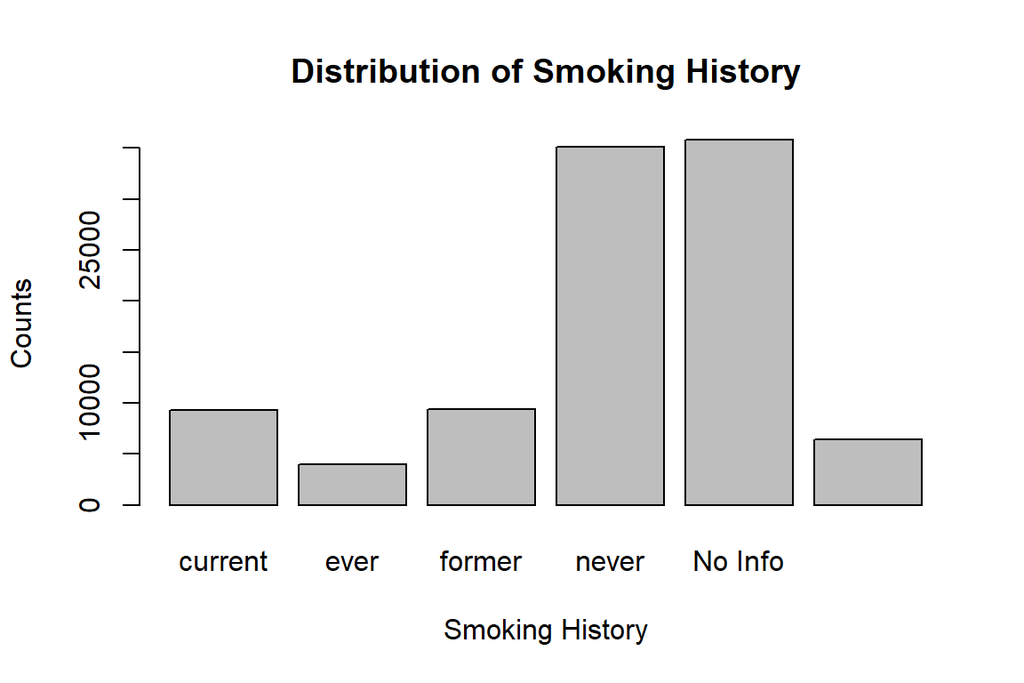

```r
freq.tbl_5 = table(diabetes$smoking_history)
barplot(freq.tbl_5, xlab="Smoking History", ylab = "Counts", main="Distribution of Smoking History")
```

- The graph above represents the distribution of smoking history. The answer mostly is “never” or “No Info”.

## 2.2 Summary of Numerical Variables

In this section, we will see the summary of the numerical variables and use boxplot to check the normality to determine if we need to use scaling to build our formula.

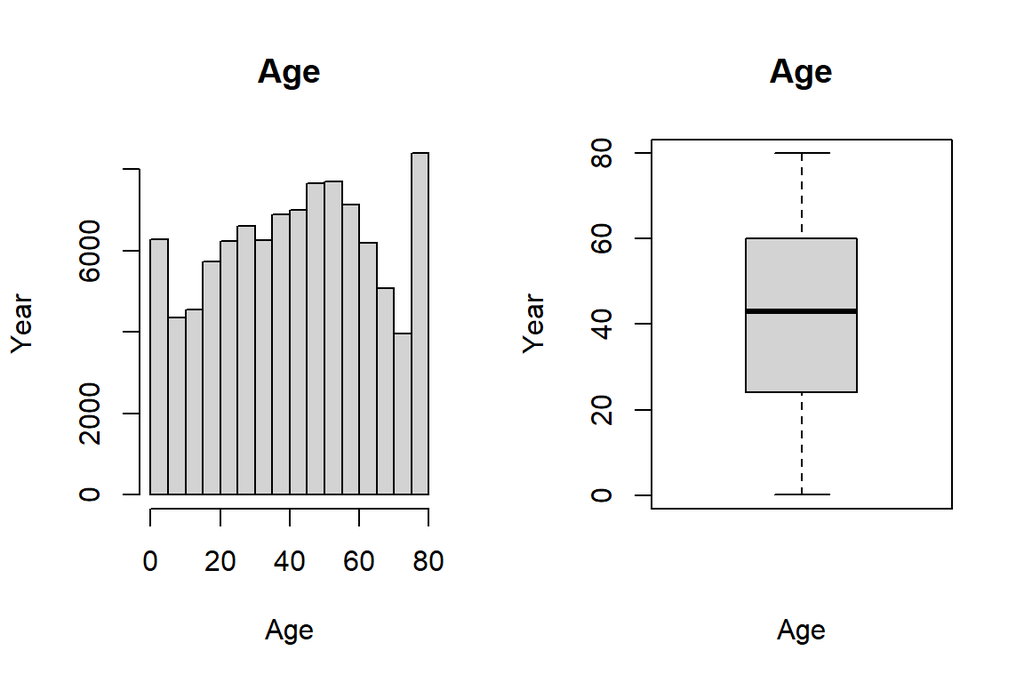

```r
par(mfrow=c(1,2))
hist(diabetes$age, xlab = "Age", ylab = "Year", main = "Age")
boxplot(diabetes$age, xlab = "Age", ylab = "Year", main = "Age")
```

- The above graphs show the distribution of age. We see that the age is equally distributed.

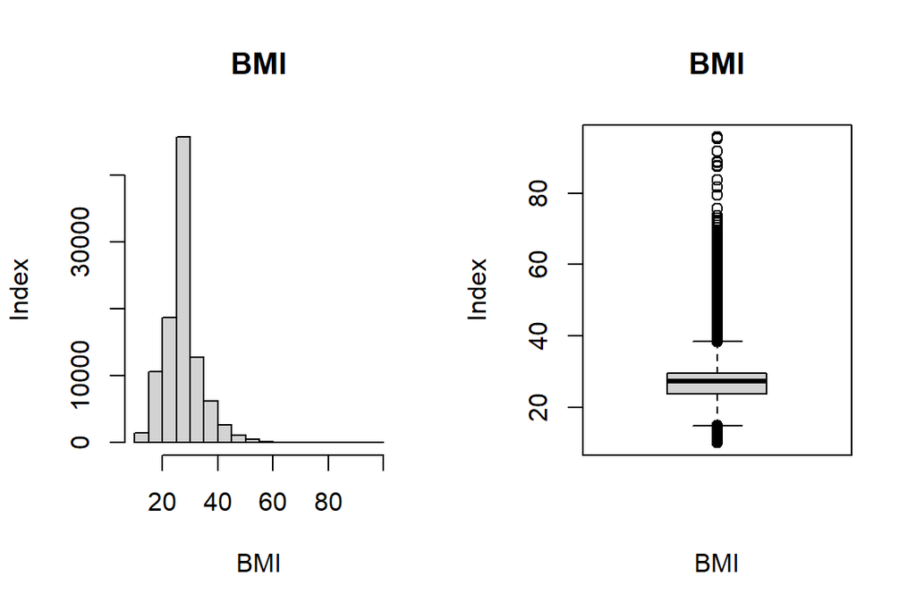

```r
par(mfrow=c(1,2))
hist(diabetes$bmi, xlab = "BMI", ylab = "Index", main = "BMI")
boxplot(diabetes$bmi, xlab = "BMI", ylab = "Index", main = "BMI")
```

- The above graphs show the distribution of BMI. We see from the histogram that the diagram is skewed to the right.

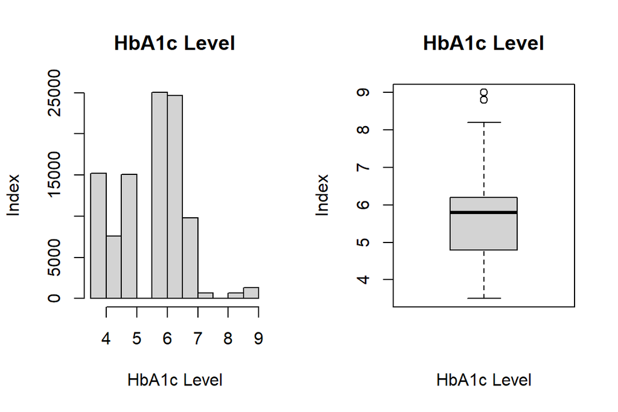

```r
par(mfrow=c(1,2))
hist(diabetes$HbA1c_level, xlab = "HbA1c Level", ylab = "Index", main = "HbA1c Level")
boxplot(diabetes$HbA1c_level, xlab = "HbA1c Level", ylab = "Index", main = "HbA1c Level")
```

- The above graphs show the distribution of HbA1c level.

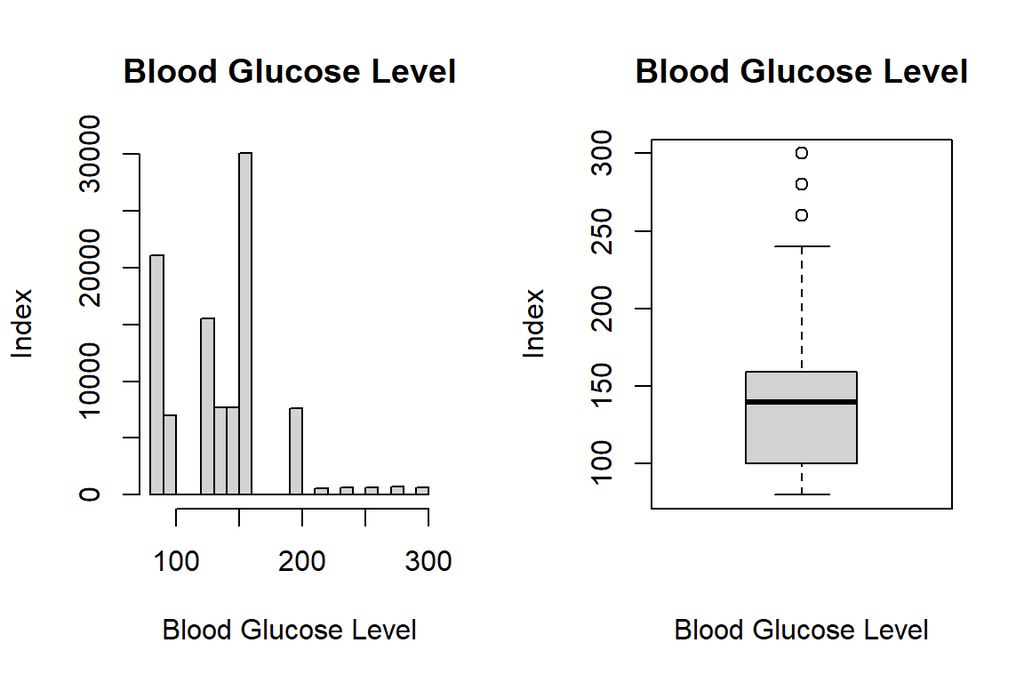

```r
par(mfrow=c(1,2))
hist(diabetes$blood_glucose_level, xlab = "Blood Glucose Level", ylab = "Index", main = "Blood Glucose Level")
boxplot(diabetes$blood_glucose_level, xlab = "Blood Glucose Level", ylab = "Index", main = "Blood Glucose Level")
```

- The above graphs show the distribution of blood glucose level. We see that the diagram is skewed to the right.

### 2.2.1 Checking for the Normality

We see that the boxplot for BMI and blood glucose level are skewed to the right. Therefore, we will use min-max scaling method to scale the numerical variables.

# 3 Logistic Regression Analysis

The purpose of the logistic regression analysis is to find out if we can use the predictor variables to predict our response variable: Diabetes. The purpose of this analysis will be a predictive analysis.

The response variable: Diabetes

Predictor variables:

Here below we are trying to build the initial model.

- **Build an Initial Model**

First, we build a logistic regression model that contains all predictor variables in the dataset. This model called the full model.

```r
# We create the ID variable to build our model.
diabetes$genderID <- as.numeric(diabetes$gender)
diabetes$smoking_historyID <- as.numeric(diabetes$smoking_history)
```

```r
initial.model = glm(diabetes ~ genderID + age + hypertension + heart_disease + smoking_historyID
                    + bmi + HbA1c_level + blood_glucose_level, family = binomial, data = diabetes)
coefficient.table = summary(initial.model)$coef
kable(coefficient.table, caption = "Significance tests of logistic regression model")
```

Significance tests of logistic regression model

|  | Estimate | Std. Error | z value | Pr(>\|z\|) |
| --- | --- | --- | --- | --- |
| (Intercept) | -27.2069189 | 0.2975222 | -91.444995 | 0 |
| genderID | 0.2547450 | 0.0357809 | 7.119580 | 0 |
| age | 0.0467033 | 0.0011011 | 42.416603 | 0 |
| hypertension | 0.7752688 | 0.0469402 | 16.516104 | 0 |
| heart_disease | 0.7295988 | 0.0604112 | 12.077210 | 0 |
| smoking_historyID | -0.1251983 | 0.0130490 | -9.594444 | 0 |
| bmi | 0.0909407 | 0.0025421 | 35.774315 | 0 |
| HbA1c_level | 2.3391997 | 0.0356496 | 65.616392 | 0 |
| blood_glucose_level | 0.0333663 | 0.0004805 | 69.439066 | 0 |

All of the p-value for the variables are less than alpha = 0.05. Next, we search for the best model using automatic variable procedure to search the final model.

- **Automatic Variable Selection**

The age, BMI and blood glucose level are practically important, we will include these three variables in the final model regardless of the statistical significance.

In summary, we define two models: the full model and the reduced model. The final optimal model will be chosen between these two models. A summary table of the significant tests is provided below.

```r
full.model = initial.model
reduced.model = glm(diabetes ~ age + bmi + blood_glucose_level , family = binomial, data = diabetes)
backward.model =  step(full.model,
                    scope=list(lower=formula(reduced.model),upper=formula(full.model)),
                    data = diabetes,
                    direction = "backward",
                    trace = 0)
final.model.coef = summary(backward.model)$coef
kable(final.model.coef , caption = "Summary table of significant tests")
```

Summary table of significant tests

|  | Estimate | Std. Error | z value | Pr(>\|z\|) |
| --- | --- | --- | --- | --- |
| (Intercept) | -27.2069189 | 0.2975222 | -91.444995 | 0 |
| genderID | 0.2547450 | 0.0357809 | 7.119580 | 0 |
| age | 0.0467033 | 0.0011011 | 42.416603 | 0 |
| hypertension | 0.7752688 | 0.0469402 | 16.516104 | 0 |
| heart_disease | 0.7295988 | 0.0604112 | 12.077210 | 0 |
| smoking_historyID | -0.1251983 | 0.0130490 | -9.594444 | 0 |
| bmi | 0.0909407 | 0.0025421 | 35.774315 | 0 |
| HbA1c_level | 2.3391997 | 0.0356496 | 65.616392 | 0 |
| blood_glucose_level | 0.0333663 | 0.0004805 | 69.439066 | 0 |

- **Interpretation**

- **Predictive Analysis**

We use the final model to predict the status of successful introduction based on the updated predictor variable values for two individuals.

```r
mynewdata = data.frame(genderID =c(1, 2),
                       age = c(25, 68),
                       hypertension = c(0,1),
                       heart_disease = c(1, 0),
                       smoking_historyID = c(3 ,4),
                       bmi = c(25.25 ,31.75),
                       HbA1c_level = c(8, 3.5),
                       blood_glucose_level = c(165 ,85))
pred.success.prob = predict(backward.model, newdata = mynewdata, type="response")
##
## threshold probability
cut.off.prob = 0.5
pred.response = ifelse(pred.success.prob > cut.off.prob, 1, 0)  # This predicts the response
## Add the new predicted response to Mynewdata
mynewdata$Pred.Response = pred.response
##
kable(mynewdata, caption = "Predicted Value of response variable
      with the given cut-off probability")
```

Predicted Value of response variable with the given cut-off probability

| genderID | age | hypertension | heart_disease | smoking_historyID | bmi | HbA1c_level | blood_glucose_level | Pred.Response |
| --- | --- | --- | --- | --- | --- | --- | --- | --- |
| 1 | 25 | 0 | 1 | 3 | 25.25 | 8.0 | 165 | 1 |
| 2 | 68 | 1 | 0 | 4 | 31.75 | 3.5 | 85 | 0 |

We used random value to test if the model can predict the person has diabetes or not and this is the predicted status of the successful introduction of the two individuals is attached to the two new records.

# 4 Subsetting and Scaling Data

Because the boxplot for BMI and blood glucose level are skewed to the right, we use min-max scaling method to scale all the numerical variables in the dataset.

```r
## feature scaling
diabetes$BMIscale = (diabetes$bmi-min(diabetes$bmi))/(max(diabetes$bmi) - min(diabetes$bmi))

diabetes$HbA1c_levelscale = (diabetes$HbA1c_level-min(diabetes$HbA1c_level))/(max(diabetes$HbA1c_level) - min(diabetes$HbA1c_level))

diabetes$agescale = (diabetes$age-min(diabetes$age))/(max(diabetes$age) - min(diabetes$age))

diabetes$glucosescale = (diabetes$blood_glucose_level-min(diabetes$blood_glucose_level))/(max(diabetes$blood_glucose_level) - min(diabetes$blood_glucose_level))
```

# 5 Creating Model Formula

Here we will create the model formula for our Neural Networks.

```r
diabetesModelDesignMatrix = model.matrix(~ gender +  hypertension + heart_disease + new_smoking_history + diabetes + BMIscale + HbA1c_levelscale + agescale + glucosescale, data = diabetes)
# The following will list all numerical variables and automatically derived dummy variables
colnames(diabetesModelDesignMatrix)
```

```
 [1] "(Intercept)"                    "genderMale"
 [3] "genderOther"                    "hypertension"
 [5] "heart_disease"                  "new_smoking_historyever"
 [7] "new_smoking_historyformer"      "new_smoking_historynever"
 [9] "new_smoking_historyNo_Info"     "new_smoking_historynot_current"
[11] "diabetes"                       "BMIscale"
[13] "HbA1c_levelscale"               "agescale"
[15] "glucosescale"
```

- Dummy variables `genderMale` and `genderOther` are defined based on the categorical variable `gender`.
- Dummy variables `new_smoking_historyever`, `new_smoking_historyformer`, `new_smoking_historynever`, `new_smoking_historyNo_Info` and `new_smoking_historynot_current` are defined based on the categorical variable `smoking history`. The object in the code above specifies the design matrix that will be utilized in the underlying model.

Here, we create a data frame that contains the feature variables to be included in the neural network model.

```r
implicitFormulaDesignMatrix = model.matrix( ~gender +  hypertension + heart_disease + new_smoking_history + diabetes + BMIscale + HbA1c_levelscale + agescale + glucosescale, data = diabetes)
colnames(implicitFormulaDesignMatrix)
```

```
 [1] "(Intercept)"                    "genderMale"
 [3] "genderOther"                    "hypertension"
 [5] "heart_disease"                  "new_smoking_historyever"
 [7] "new_smoking_historyformer"      "new_smoking_historynever"
 [9] "new_smoking_historyNo_Info"     "new_smoking_historynot_current"
[11] "diabetes"                       "BMIscale"
[13] "HbA1c_levelscale"               "agescale"
[15] "glucosescale"
```

The code above generates the same set of features, including automatically created dummy variables.

After setting up the design matrix with explicitly specified dummy variables for the relevant categorical variables, we apply the string function to define the model formula.

```r
columnNames = colnames(implicitFormulaDesignMatrix)
columnList = paste(columnNames[-c(1,length(columnNames))], collapse = "+")
columnList = paste(c(columnNames[length(columnNames)],"~",columnList), collapse="")
modelFormula = formula(columnList)
modelFormula
```

```
glucosescale ~ genderMale + genderOther + hypertension + heart_disease +
    new_smoking_historyever + new_smoking_historyformer + new_smoking_historynever +
    new_smoking_historyNo_Info + new_smoking_historynot_current +
    diabetes + BMIscale + HbA1c_levelscale + agescale
```

## 5.1 Building Perceptron Model

```r
NetworkModel = neuralnet(modelFormula,
                         data = implicitFormulaDesignMatrix,  # must be the design matrix
                         hidden = 1,
                         act.fct = "logistic",     # sigmoid activation function
                         linear.output = FALSE
                         )
kable(NetworkModel$result.matrix)
```

| error | 1711.9177762 |
| --- | --- |
| reached.threshold | 0.0087396 |
| steps | 62.0000000 |
| Intercept.to.1layhid1 | 5.3994193 |
| genderMale.to.1layhid1 | 4.8808991 |
| genderOther.to.1layhid1 | -4.5934862 |
| hypertension.to.1layhid1 | 1.2048445 |
| heart_disease.to.1layhid1 | 0.5579900 |
| new_smoking_historyever.to.1layhid1 | 5.1384488 |
| new_smoking_historyformer.to.1layhid1 | 5.5831272 |
| new_smoking_historynever.to.1layhid1 | 4.9983732 |
| new_smoking_historyNo_Info.to.1layhid1 | 3.2271952 |
| new_smoking_historynot_current.to.1layhid1 | 5.3571724 |
| diabetes.to.1layhid1 | -2.3247561 |
| BMIscale.to.1layhid1 | 5.3032240 |
| HbA1c_levelscale.to.1layhid1 | 6.5951661 |
| agescale.to.1layhid1 | 5.6538983 |
| Intercept.to.glucosescale | 0.2064265 |
| 1layhid1.to.glucosescale | -1.2322263 |

The table above presents the estimated weights in the perceptron model. Now, we will generate a visual representation of this model.

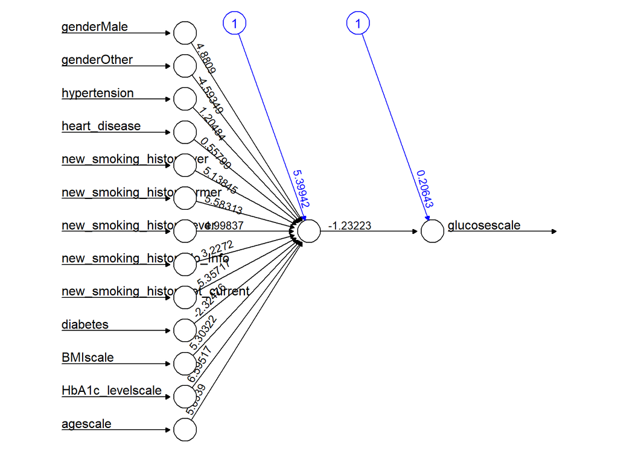

```r
plot(NetworkModel, rep="best")
```

# 6 Prediction and ROC Analysis for Logistic and Preceptron

We will construct the ROC curve for the perceptron model using the entire dataset to enable a fair comparison of the ROC curves and corresponding AUCs among the logistic prediction models and the perceptron model.

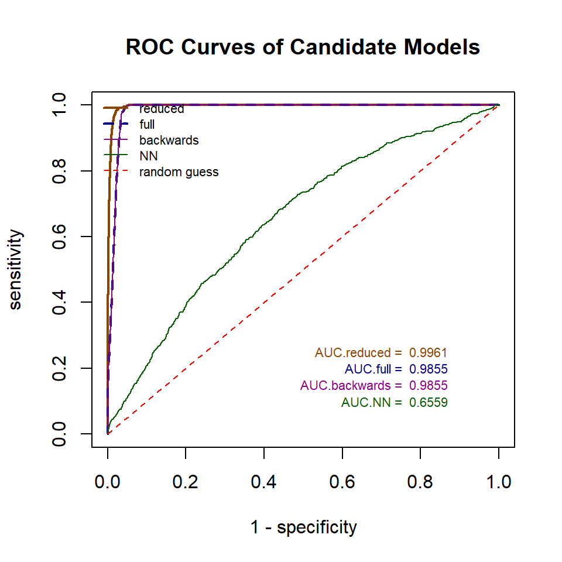

ROC curves comparing the model performance of the three logistic models and a single-layer neural network.

```r
predNN = predict(NetworkModel, newdata = implicitFormulaDesignMatrix, linear.output = FALSE)
preReduced = predict(reduced.model, newdata = diabetes,type="response" )
predfullModel = predict(full.model, newdata = diabetes,type="response" )
predbackwards = predict(backward.model, newdata = diabetes,type="response" )
##
##
prediction.reduced = preReduced
prediction.full = predfullModel
prediction.backwards = predbackwards
  category = diabetes$glucosescale == 1
  ROCobj.reduced <- roc(category, prediction.reduced)
  ROCobj.full <- roc(category, prediction.full)
  ROCobj.backwards <- roc(category, prediction.backwards)
  ROCobj.NN <-roc(category, predNN)
## AUC
  reducedAUC = ROCobj.reduced$auc
  fullAUC = ROCobj.full$auc
  backwardsAUC = ROCobj.backwards$auc
  NNAUC = ROCobj.NN$auc
## extract sensitivity and specificity from candidate models
  sen.reduced = ROCobj.reduced$sensitivities
  fnr.reduced = 1 - ROCobj.reduced$specificities
  #
  sen.full = ROCobj.full$sensitivities
  fnr.full = 1 - ROCobj.full$specificities
  #
  sen.backwards = ROCobj.backwards$sensitivities
  fnr.backwards = 1 - ROCobj.backwards$specificities
  #
  sen.NN = ROCobj.NN$sensitivities
  fnr.NN = 1 - ROCobj.NN$specificities

## Fond contrast color for ROC curves
  colors = c("#8B4500", "#00008B", "#8B008B", "#055d03")
## Plotting ROC curves
#par(type="s")
plot(fnr.reduced, sen.reduced, type = "l", lwd = 2, col = colors[1],
     xlim = c(0,1),
     ylim = c(0,1),
     xlab = "1 - specificity",
     ylab = "sensitivity",
     main = "ROC Curves of Candidate Models")
lines(fnr.full, sen.full, lwd = 2, lty = 2, col = colors[2])
lines(fnr.backwards, sen.backwards, lwd = 1, col = colors[3])
lines(fnr.NN, sen.NN, lwd = 1, col = colors[4])

segments(0,0,1,1, lwd =1, col = "red", lty = 2)
legend("topleft", c("reduced", "full", "backwards", "NN", "random guess"),
       col=c(colors, "red"), lwd=c(2,2,1,1,1),
       lty=c(1,2,1,1,2), bty = "n", cex = 0.7)
## annotating AUC
text(0.87, 0.25, paste("AUC.reduced = ", round(reducedAUC,4)), col=colors[1], cex = 0.7, adj = 1)
text(0.87, 0.20, paste("AUC.full = ", round(fullAUC,4)), col=colors[2], cex = 0.7, adj = 1)
text(0.87, 0.15, paste("AUC.backwards = ", round(backwardsAUC,4)), col=colors[3], cex = 0.7, adj = 1)
text(0.87, 0.10, paste("AUC.NN = ", round(NNAUC,4)), col=colors[4], cex = 0.7, adj = 1)
```

# 7 ROC Analysis for Decision Tree Algorithms

We will set up a random split approach.

```r
# We use a random split approach
n = dim(diabetes)[1]  # sample size
# caution: using without replacement
train.id = sample(1:n, round(0.7*n), replace = FALSE)
train = diabetes[train.id, ]    # training data
test = diabetes[-train.id, ]    # testing data
```

## 7.1 Model of Decision Tree

Here, we create a wrapper to build different decision trees.

```r
# arguments to pass into rpart():
# 1. data set (training /testing);
# 2. Penalty coefficients
# 3. Impurity measure
##
tree.builder = function(in.data, fp, fn, purity){
   tree = rpart(diabetes ~ .,                # including all features
                data = in.data,
                na.action  = na.rpart,       # By default, deleted if the outcome is missing,
                                             # kept if predictors are missing
                method = "class",            # Classification form factor
                model  = FALSE,
                x = FALSE,
                y = TRUE,
            parms = list( # loss matrix. Penalize false positives or negatives more heavily
                         loss = matrix(c(0, fp, fn, 0), ncol = 2, byrow = TRUE),
                         split = purity),          # "gini" or "information"
             ## rpart algorithm options (These are defaults)
             control = rpart.control(
                        minsplit = 10,  # minimum number of observations required before split
                        minbucket= 10,  # minimum number of observations in
                                        # any terminal node, default = minsplit/3
                        cp  = 0.01,  # complexity parameter for stopping rule,
                                     # 0.02 -> small tree
                       xval = 10     # number of cross-validation )
                        )
             )
  }
```

Using the above function, we define six different decision tree models in the following.

- Model 1: `gini.tree.11` is based on the Gini index without penalizing false positives and false negatives.
- Model 2: `into.tree.11` is based on the entropy without penalizing false positives and false negatives.
- Model 3: `gini.tree.1.10` is based on the Gini index with the cost of false positive is 1 and false negative is 10.
- Model 4: `into.tree.1.10` is based on the entropy with the cost of false positive is 1 and false negative is 10.
- Model 5: `gini.tree.10.1` is based on the Gini index with the cost of false positive is 10 and false negative is 1.
- Model 6: `into.tree.10.1` is based on the entropy with the cost of false positive is 10 and false negative is 1.

The tree diagram of Model 1 and Model 2 is shown below.

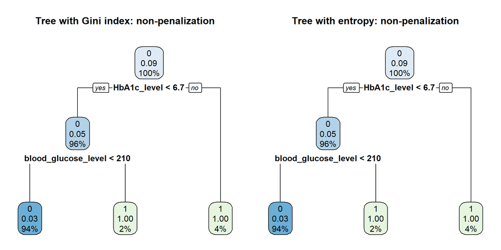

Non-penalized decision tree models using Gini index (left) and entropy (right)

```r
## Call the tree model wrapper.
gini.tree.1.1 = tree.builder(in.data = train, fp = 1, fn = 1, purity = "gini")
info.tree.1.1 = tree.builder(in.data = train, fp = 1, fn = 1, purity = "information")
gini.tree.1.10 = tree.builder(in.data = train, fp = 1, fn = 10, purity = "gini")
info.tree.1.10 = tree.builder(in.data = train, fp = 1, fn = 10, purity = "information")
gini.tree.10.1 = tree.builder(in.data = train, fp = 10, fn = 1, purity = "gini")
info.tree.10.1 = tree.builder(in.data = train, fp = 10, fn = 1, purity = "information")
## tree plots
par(mfrow=c(1,2))
rpart.plot(gini.tree.1.1, main = "Tree with Gini index: non-penalization")
rpart.plot(info.tree.1.1, main = "Tree with entropy: non-penalization")
```

The tree diagram of Model 3 and Model 4 is shown below.

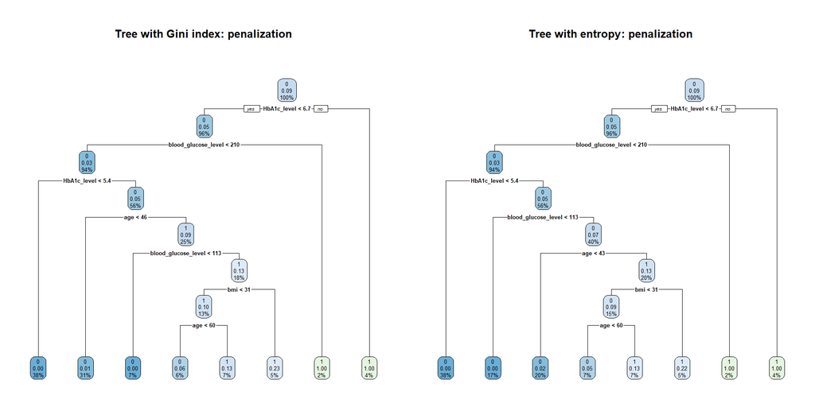

Penalized decision tree models using Gini index (left) and entropy (right)

```r
par(mfrow=c(1,2))
rpart.plot(gini.tree.1.10, main = "Tree with Gini index: penalization")
rpart.plot(info.tree.1.10, main = "Tree with entropy: penalization")
```

The tree diagram of Model 5 and Model 6 is shown below.

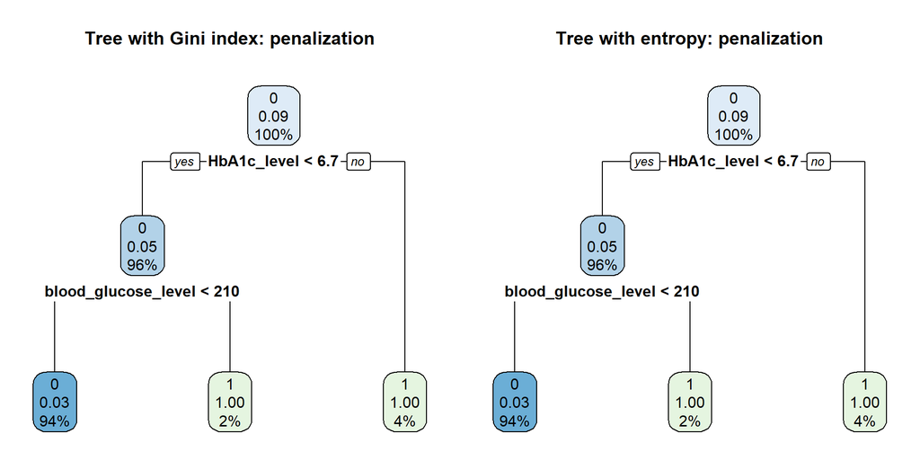

Penalized decision tree models using Gini index (left) and entropy (right)

```r
par(mfrow=c(1,2))
rpart.plot(gini.tree.10.1, main = "Tree with Gini index: penalization")
rpart.plot(info.tree.10.1, main = "Tree with entropy: penalization")
```

## 7.2 ROC for Model Selection

Previously, we built six different decision tree models. Next, we use ROC analysis to identify the best model out of the six candidates.

```r
# function returning a sensitivity and specificity matrix
SenSpe = function(in.data, fp, fn, purity){
  cutoff = seq(0,1, length = 20)   # 20 cut-offs including 0 and 1.
  model = tree.builder(in.data, fp, fn, purity)
  ## Caution: decision tree returns both "success" and "failure" probabilities.
  ## We need only "success" probability to define sensitivity and specificity!!!
  pred = predict(model, newdata = in.data, type = "prob") # two-column matrix.
  senspe.mtx = matrix(0, ncol = length(cutoff), nrow= 2, byrow = FALSE)
  for (i in 1:length(cutoff)){
  # CAUTION: "1" and "0" are values of the label in this data set!
  # The following line uses only "1" probability: pred[, "1"] !!!!
  pred.out =  ifelse(pred[,"1"] >= cutoff[i], "1", "0")
  TP = sum(pred.out =="1" & in.data$diabetes == "1")
  TN = sum(pred.out =="0" & in.data$diabetes == "0")
  FP = sum(pred.out =="1" & in.data$diabetes == "0")
  FN = sum(pred.out =="0" & in.data$diabetes == "1")
  senspe.mtx[1,i] = TP/(TP + FN)
  senspe.mtx[2,i] = TN/(TN + FP)
  }
  ## A better approx of ROC, need library {pROC}
  prediction = pred[, "1"]
  category = in.data$diabetes == "1"
  ROCobj <- roc(category, prediction)
  AUC = auc(ROCobj)
  ##
  list(senspe.mtx= senspe.mtx, AUC = round(AUC,3))
 }
```

The function above includes three arguments that allow users to select various types of decision trees, including the six discussed in the previous subsection. Then, we use this function to construct six different tress and plot their corresponding ROC curves to assess the overall performance of these tree algorithms.

```r
giniROC11 = SenSpe(in.data = train, fp=1, fn=1, purity="gini")
infoROC11 = SenSpe(in.data = train, fp=1, fn=1, purity="information")
giniROC110 = SenSpe(in.data = train, fp=1, fn=10, purity="gini")
infoROC110 = SenSpe(in.data = train, fp=1, fn=10, purity="information")
giniROC101 = SenSpe(in.data = train, fp=10, fn=1, purity="gini")
infoROC101 = SenSpe(in.data = train, fp=10, fn=1, purity="information")
```

Next, we plot the ROC curves and calculate the areas under the ROC curves for individual decision tree models.

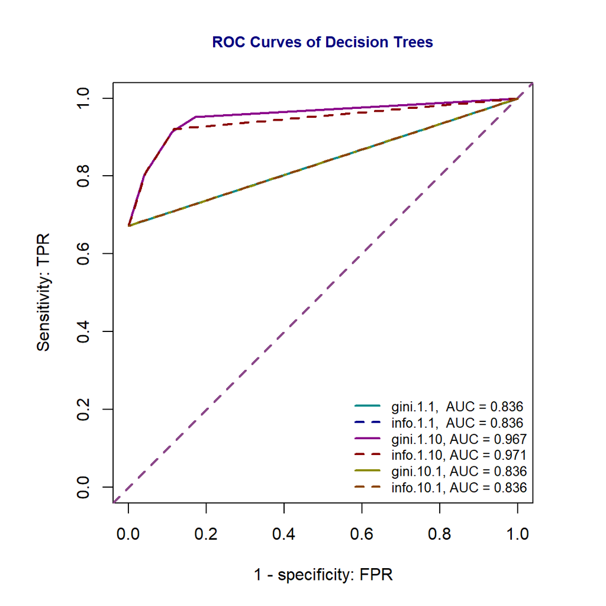

Comparison of ROC curves

```r
par(pty="s")      # set up square plot through graphic parameter
colors = c("#008B8B", "#00008B",  "#8B008B",  "#8B0000",  "#8B8B00", "#8B4500")
plot(1-giniROC11$senspe.mtx[2,], giniROC11$senspe.mtx[1,],
     type = "l",
     xlim=c(0,1),
     ylim=c(0,1),
     xlab="1 - specificity: FPR", ylab="Sensitivity: TPR",
     col = colors[1],
     lwd = 2,
     main="ROC Curves of Decision Trees",
     cex.main = 0.9,
     col.main = "navy")
abline(0,1, lty = 2, col = "orchid4", lwd = 2)
lines(1-infoROC11$senspe.mtx[2,], infoROC11$senspe.mtx[1,],
      col = colors[2], lwd = 2, lty=2)
lines(1-giniROC110$senspe.mtx[2,], giniROC110$senspe.mtx[1,],
      col = colors[3], lwd = 2)
lines(1-infoROC110$senspe.mtx[2,], infoROC110$senspe.mtx[1,],
      col = colors[4], lwd = 2, lty=2)
lines(1-giniROC101$senspe.mtx[2,], giniROC101$senspe.mtx[1,],
      col = colors[5], lwd = 2, lty = 4)
lines(1-infoROC101$senspe.mtx[2,], infoROC101$senspe.mtx[1,],
      col = colors[6], lwd = 2, lty=2)
legend("bottomright", c(paste("gini.1.1,  AUC =", giniROC11$AUC),
                        paste("info.1.1,  AUC =",infoROC11$AUC),
                        paste("gini.1.10, AUC =",giniROC110$AUC),
                        paste("info.1.10, AUC =",infoROC110$AUC),
                        paste("gini.10.1, AUC =",giniROC101$AUC),
                        paste("info.10.1, AUC =",infoROC101$AUC)),
                        col=colors,
                        lty=rep(1:2,3), lwd=rep(2,6), cex = 0.8, bty = "n")
```

The above ROC curves represent various decision trees and their corresponding AUC. The model of `info.1.10`: based on the entropy with the cost of false positive is 1 and false negative is 10 is considered the best decision tree model among the existing ones because it has the highest AUC out of all of models.

# 8 ROC Analysis for BAGGING Algorithms

In this section, we will have the ROC Analysis for BAGGING algorithms.

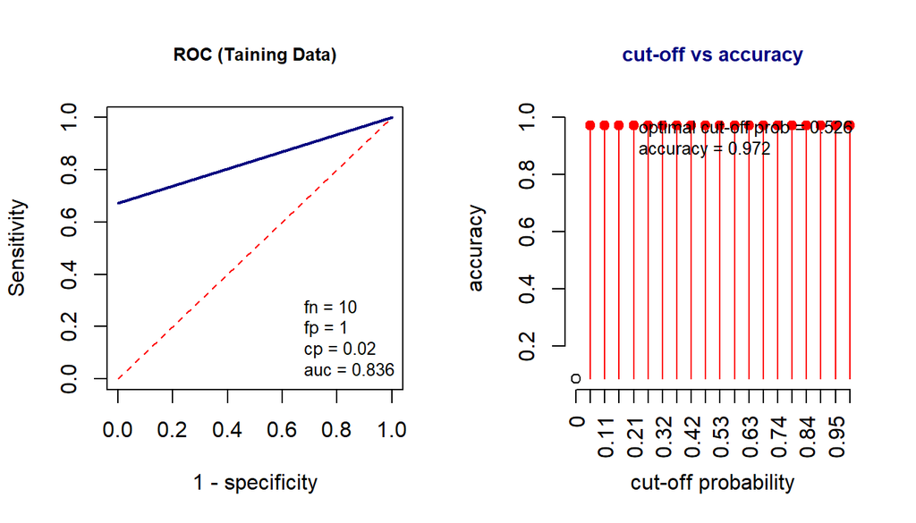

The ROC curve and the plot for optimal cut-off determination

```r
##
Diabetes.bag.train <- bagging(as.factor(diabetes) ~ .,
                              data = train,
                              nbagg = 150,    # number of trees
                              coob = TRUE,
                              parms = list(loss = matrix(c(0, 10, 1, 0),
                                                          ncol = 20,
                                                          byrow = TRUE),
                                                          split = "gini"),
                              control = rpart.control(minsplit = 10,
                                                      cp = 0.02))
### predict() returns either "class" or "prob" in the classification
### When specifying type = "class", the default cut-off of 0.5 is used.
pred = predict(Diabetes.bag.train, train, type = "prob")
### Optimal cut-off probability identification: no cross-validation is needed
cut.prob = seq(0,1, length = 20)
  senspe.mtx = matrix(0, ncol = length(cut.prob), nrow= 3, byrow = FALSE)
  for (i in 1:length(cut.prob)){
  # CAUTION: "1" and "0" are values of the label in this data set!
  # The following line uses only "1" probability: pred[, "1"] !!!!
  pred.out =  ifelse(pred[,"1"] >= cut.prob[i], "1", "0")
  TP = sum(pred.out =="1" & train$diabetes == "1")
  TN = sum(pred.out =="0" & train$diabetes == "0")
  FP = sum(pred.out =="1" & train$diabetes == "0")
  FN = sum(pred.out =="0" & train$diabetes == "1")
  senspe.mtx[1,i] = TP/(TP + FN)                  # sensitivity
  senspe.mtx[2,i] = TN/(TN + FP)                  # specificity
  senspe.mtx[3,i] = (TP+TN)/(TP + FN + TN + FP)   # accuracy
  }
  ## A better approx of ROC, need library {pROC}
  prediction = pred[, "1"]
  category = train$diabetes == "1"
  ROCobj <- roc(category, prediction)
  AUC = auc(ROCobj)
  AUC = round(as.vector(AUC[1]),3)
  ###
  n = length(senspe.mtx[3,])
  idx = which(senspe.mtx[3,] == max(senspe.mtx[3,]))
  tick.label = as.character(round(cut.prob,2))
  ###
  par(mfrow = c(1,2))
  plot(1-senspe.mtx[2,], senspe.mtx[1,],
       type="l",
       lwd = 2,
       col = "navy",
       xlim=c(0,1),
       ylim = c(0,1),
       xlab = "1 - specificity",
       ylab = "Sensitivity",
       main = "ROC (Taining Data)",
       cex.main = 0.8)
  # Adding off diagonal line representing random guess
  segments(0, 0, 1, 1, lty = 2, col = "red", )
  legend("bottomright",c("fn = 10", "fp = 1", "cp = 0.02", paste("auc =", AUC)), bty="n", cex = 0.8)

  plot(1:length(cut.prob), senspe.mtx[3,],
       xlab="cut-off probability",
       ylab = "accuracy",
       ylim=c(min(senspe.mtx[3,]),1),
       axes = FALSE,
       main="cut-off vs accuracy",
       cex.main = 0.9,
       col.main = "navy")
       # Adding axes and other graphical components to the plot
       axis(1, at=1:20, label = tick.label, las = 2)
       axis(2)
       points(idx, senspe.mtx[3,][idx], pch=19, col = "red")
       segments(idx , min(senspe.mtx[3,]), idx , senspe.mtx[3,][idx ], col = "red")
       #text(idx, senspe.mtx[3,][idx]+0.03, as.character(round(senspe.mtx[3,][idx],4)),
       #     col = "red", cex = 0.8)
       legend("topright", c(paste("optimal cut-off prob = ",round(median(cut.prob[idx]),3), sep=""),
                            paste("accuracy = ", round(mean(senspe.mtx[3,][idx ]),3), sep="")),
                          cex = 0.8, bty = "n", adj = -0)
```

# 9 Conclusion

We did ROC curves analysis for logistic, perceptron, decision tree, and BAGGING algorithms.

```r
conclusion.model.coef = summary(reduced.model)$coef
kable(conclusion.model.coef , caption = "Summary table of reduced logistic model")
```

Summary table of reduced logistic model

|  | Estimate | Std. Error | z value | Pr(>\|z\|) |
| --- | --- | --- | --- | --- |
| (Intercept) | -13.1031437 | 0.1141369 | -114.80200 | 0 |
| age | 0.0516858 | 0.0008612 | 60.01840 | 0 |
| bmi | 0.0937951 | 0.0020004 | 46.88775 | 0 |
| blood_glucose_level | 0.0332924 | 0.0003783 | 87.99455 | 0 |

The reduced model is: diabetes ~ age + bmi + blood_glucose_level. The variable of age, BMI and blood glucose level have positive correlation with diabetes. Other variables might be a confounding factors. Therefore, we choose the reduced model that provide us a higher accuracy than the other models. We use the reduced model to predict diabetes, from the full logistic model, we find out that the other predictor variables are also correlated to diabetes. Since our goal is to predict diabetes, we choose the reduced model with higher accuracy.